# Условие 1: Задача 1

- Постройте график
- Назовите график
- Сделайте именование оси x и оси y
- Сделайте выводы

### 1.1. Скачать следующие данные: kc-house-data

```python
import pandas as pd
import matplotlib.pyplot as plt
import seaborn as sns
import numpy as np

df = pd.read_csv('kc_house_data.csv')
df.head()
```

|  | id | date | price | bedrooms | bathrooms | sqft_living | sqft_lot | floors | waterfront | view | ... | grade | sqft_above | sqft_basement | yr_built | yr_renovated | zipcode | lat | long | sqft_living15 | sqft_lot15 |
| --- | --- | --- | --- | --- | --- | --- | --- | --- | --- | --- | --- | --- | --- | --- | --- | --- | --- | --- | --- | --- | --- |
| 0 | 7129300520 | 20141013T000000 | 221900.0 | 3 | 1.00 | 1180 | 5650 | 1.0 | 0 | 0 | ... | 7 | 1180 | 0 | 1955 | 0 | 98178 | 47.5112 | -122.257 | 1340 | 5650 |
| 1 | 6414100192 | 20141209T000000 | 538000.0 | 3 | 2.25 | 2570 | 7242 | 2.0 | 0 | 0 | ... | 7 | 2170 | 400 | 1951 | 1991 | 98125 | 47.7210 | -122.319 | 1690 | 7639 |
| 2 | 5631500400 | 20150225T000000 | 180000.0 | 2 | 1.00 | 770 | 10000 | 1.0 | 0 | 0 | ... | 6 | 770 | 0 | 1933 | 0 | 98028 | 47.7379 | -122.233 | 2720 | 8062 |
| 3 | 2487200875 | 20141209T000000 | 604000.0 | 4 | 3.00 | 1960 | 5000 | 1.0 | 0 | 0 | ... | 7 | 1050 | 910 | 1965 | 0 | 98136 | 47.5208 | -122.393 | 1360 | 5000 |
| 4 | 1954400510 | 20150218T000000 | 510000.0 | 3 | 2.00 | 1680 | 8080 | 1.0 | 0 | 0 | ... | 8 | 1680 | 0 | 1987 | 0 | 98074 | 47.6168 | -122.045 | 1800 | 7503 |

5 rows × 21 columns

### 1.2. Изучите стоимости недвижимости

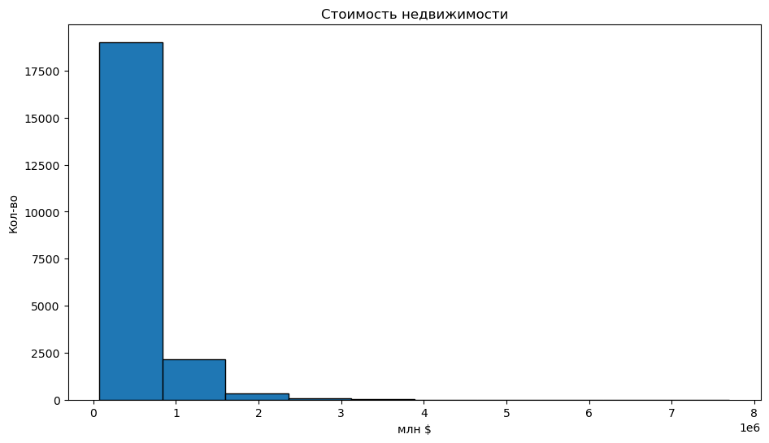

```python
plt.figure(figsize = (11, 6))
plt.hist(df['price'], edgecolor='black')
plt.title('Стоимость недвижимости')
plt.xlabel('млн $')
plt.ylabel('Кол-во');
```

Большая часть недвижимости имеет стоимость до 1 миллиона ($? не нашла описание в датасете на kaggle). Есть очень малая доля домов стоимостью более 4 млн, на графике не видны.

### 1.3. Изучите распределение квадратуры жилой площади

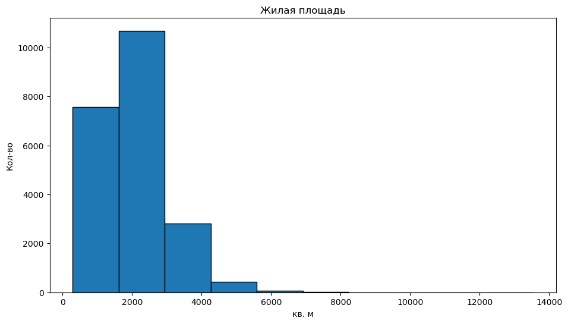

```python
plt.figure(figsize = (11, 6))
plt.hist(df['sqft_living'], edgecolor='black')
plt.title('Жилая площадь')
plt.xlabel('кв. м')
plt.ylabel('Кол-во');
```

### 1.4 Изучите распределение года постройки

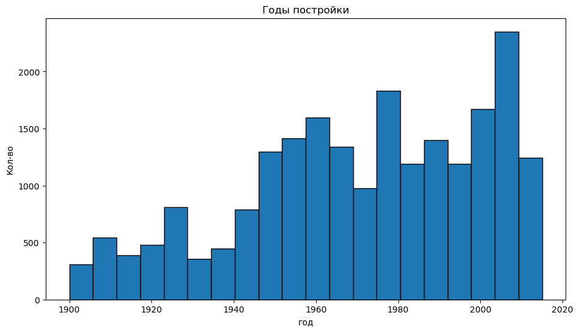

```python
plt.figure(figsize = (11, 6))
plt.hist(df['yr_built'], bins = 20, edgecolor='black')
plt.title('Годы постройки')
plt.xlabel('год')
plt.ylabel('Кол-во');
```

## Условие 2: 2 задача

### 2.1. Изучите распределение домов от наличия вида на набережную

- Постройте график
- Сделайте выводы

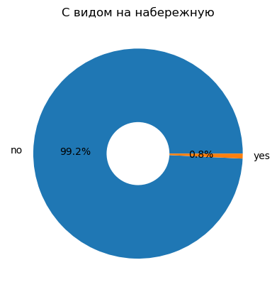

```python
data = df['waterfront'].value_counts()
data.index = ['no', 'yes']
names = data.index
values = data.values

plt.pie(values, labels=names, autopct='%.1f%%', wedgeprops=dict(width=0.7))
plt.title('С видом на набережную');
```

Менее 1 процента домов имеют вид на набережную :(

### 2.2 Изучите распределение этажей домов

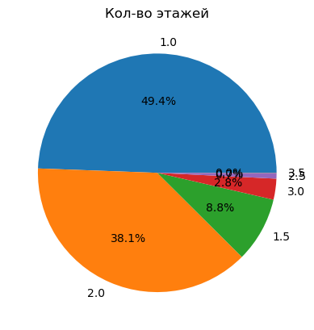

```python
data = df['floors'].value_counts()

names = data.index
values = data.values

plt.pie(values, labels=names, autopct='%.1f%%')
plt.title('Кол-во этажей');
```

Половина домов имеет 1-этажную конструкцию, 38% - 2-этажную. Также в датасете имеются дома с половинчатыми этажами

### 2.3. Изучите распределение состояния домов

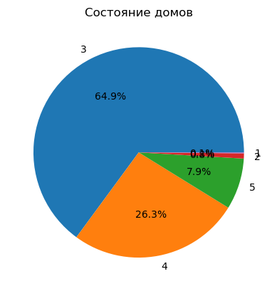

```python
data = df['condition'].value_counts()

names = data.index
values = data.values

plt.pie(values, labels=names, autopct='%.1f%%')
plt.title('Состояние домов');
```

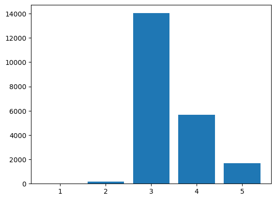

```python
plt.bar(names, values);
```

```python
data
```

```
condition
3    14031
4     5679
5     1701
2      172
1       30
Name: count, dtype: int64
```

Таким образом, почти 65% домов находятся в среднем состоянии, 26% - в хорошем и 8% - в отличном.Оставшийся 1% приходится на дома в плохом и очень плохом состоянии.

## Условие 3: 3 задача

Исследуйте, какие характеристики недвижимости влияют на стоимость недвижимости, с применением не менее 5 диаграмм из урока.

```python
df.info()
```

```
<class 'pandas.core.frame.DataFrame'>
RangeIndex: 21613 entries, 0 to 21612
Data columns (total 21 columns):
 #   Column         Non-Null Count  Dtype
---  ------         --------------  -----
 0   id             21613 non-null  int64
 1   date           21613 non-null  object
 2   price          21613 non-null  float64
 3   bedrooms       21613 non-null  int64
 4   bathrooms      21613 non-null  float64
 5   sqft_living    21613 non-null  int64
 6   sqft_lot       21613 non-null  int64
 7   floors         21613 non-null  float64
 8   waterfront     21613 non-null  int64
 9   view           21613 non-null  int64
 10  condition      21613 non-null  int64
 11  grade          21613 non-null  int64
 12  sqft_above     21613 non-null  int64
 13  sqft_basement  21613 non-null  int64
 14  yr_built       21613 non-null  int64
 15  yr_renovated   21613 non-null  int64
 16  zipcode        21613 non-null  int64
 17  lat            21613 non-null  float64
 18  long           21613 non-null  float64
 19  sqft_living15  21613 non-null  int64
 20  sqft_lot15     21613 non-null  int64
dtypes: float64(5), int64(15), object(1)
memory usage: 3.5+ MB
```

```python
df.drop(columns = ['id', 'date'], inplace=True)
corr_matrix = df.corr()
corr_matrix = np.round(corr_matrix, 1)
corr_matrix[np.abs(corr_matrix) < 0.3] = 0
```

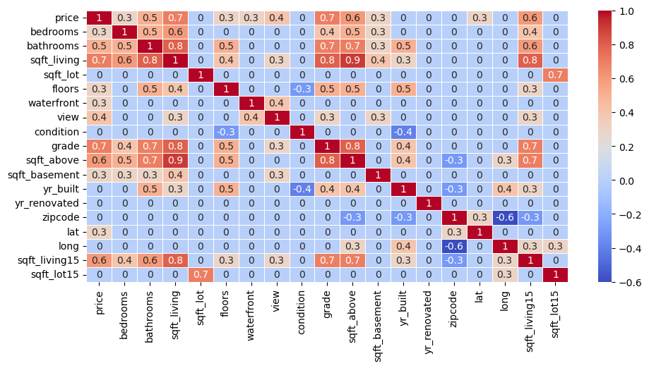

```python
plt.figure(figsize = (11,5))
sns.heatmap(corr_matrix, annot=True, linewidths=0.5, cmap='coolwarm');
```

Исследуем подробней характеристики, которые заметно коррелируют с ценой (число ванных, жилая площадь, вид, конструкция и дизайн, и площадь над землей)

### Зависимость стоимости недвижимости от кол-ва ванных комнат

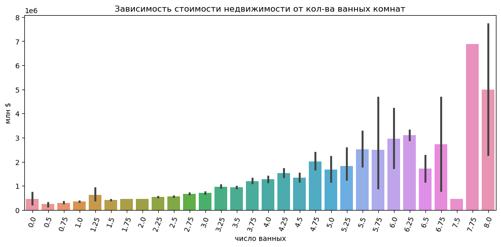

```python
plt.figure(figsize=(12, 5))

sns.barplot(x=df['bathrooms'], y=df['price'])

plt.title('Зависимость стоимости недвижимости от кол-ва ванных комнат')
plt.xlabel('число ванных')
plt.ylabel('млн $')
plt.xticks(rotation=70);
```

Как видим из столбчатой диаграммы, чем больше в доме ванных комнат, тем более дорогое жилье, что интуитивно понятно. Есть одно исключение, где ванных в доме 7.5 (дробная часть означает туалет без душа).

### Зависимость стоимости недвижимости от жилой площади

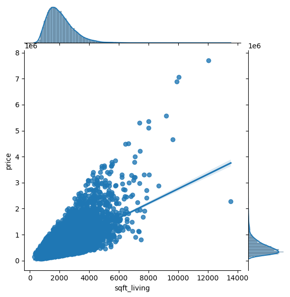

```python
sns.jointplot(x=df['sqft_living'], y=df['price'], kind='reg');
```

Довольно сильная прямая зависимость (коэф. корреляции 0.7) цены от жилой площади.

### Зависимость стоимости недвижимости от площади, находящейся над землей

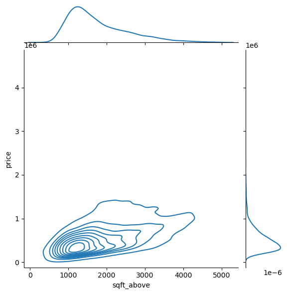

```python
df_cut = df[df['sqft_above'] < 5000]
sns.jointplot(x=df_cut['sqft_above'], y=df_cut['price'], kind='kde');
```

### Зависимость стоимости жилья от критерия вида (из окна)

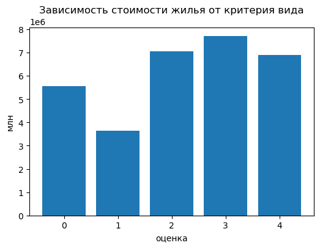

```python
plt.figure(figsize=(6, 4))

plt.bar(df['view'], df['price'])

plt.title('Зависимость стоимости жилья от критерия вида')
plt.xlabel('оценка')
plt.ylabel('млн');
```

Неочевидная зависимость: хотя основная масса высоких цен находится при оценках вида от 2 до 4, имеется достаточное количество дорогого жилья при оценке вида 0. Здесь было бы удобно посмотреть распределение цен с помощью боксплота, но к сожалению при попытках его построить, не получалось увидеть информативную диаграмму. Возможно, это связано с большим количеством строк (исключение выбросов не помогло)

[figure not shown]

```python
sns.boxplot(x=df['price'], y=df['view'], whis = 1)# showfliers=False скрывает все выбросы, whis скрывает часть выбросов

plt.title('зависимость стоимости жилья от вида из окна')
plt.xlabel('млн')
plt.ylabel('оценка');
```

### Зависимость стоимости жилья от качества

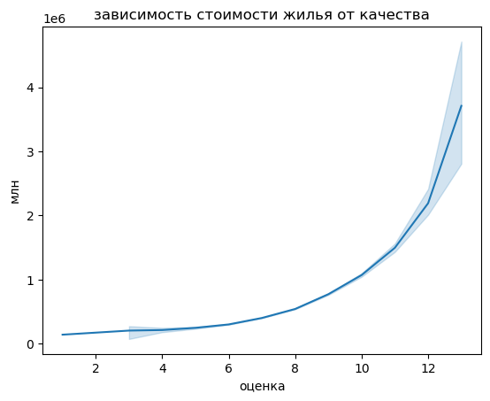

```python
sns.lineplot(x=df['grade'], y=df['price'])

plt.title('зависимость стоимости жилья от качества')
plt.xlabel('оценка')
plt.ylabel('млн');
```

Значение от 1 до 13, где 1-3 плохая конструкция здания и дизайн, 7 - средний уровень конструкции и дизайна, 11-13 - высокое качество конструкции и дизайна.

Стоимость жилья заметно увеличивается, когда оценка качества дома начинает превышать 10